# Paper: Solidarity

Ferdinand Geißler, Humboldt

Felix Hartmann, Humboldt

Macartan Humphreys, WZB and Columbia University

Heike Klüver, Humboldt

Johannes Giesecke, Humboldt

January 2022

Abstract

Respondents support high levels of cash and vaccine transfers to help poorer nations. They are more supportive when health and economic risks of failing to provide support are high; but for the most part support does not depend on these calculations. Preferences over German policy are largely independent of what other countries are doing. Median support for vaccines (90 million) and cash (2 billion) corresponds closely to actual (100 million doses and 2.2 billion cash).

# 1 Setup

```r
knitr::opts_chunk$set(echo=TRUE, warning=FALSE, message=FALSE, comment=NA)
options(qwraps2_markup = "markdown")

## Packages
if (!require(pacman)) install.packages("pacman")
```

```r
pacman::p_load(
  ggpubr,      # for ggarrange
  ggridges,    # plot
  cregg,       # conjoint
  readxl,      # read excel
  gtrendsR,    # google trends
  aod,         # hypothesis testing (1.3.1)
  car,         # linear hypothesis testing for causal tree (3.0-2)
  corrplot,    # Correlations (0.84)
  DeclareDesign,
  dplyr,       # Data manipulation (0.8.0.1)
  evtree,      # evolutionary learning of globally optimal trees (1.0-7)
  fastDummies,
  fBasics,     # Summary statistics (3042.89)
  ggplot2,
  grf,         # Generalized random forests (0.10.2)
  haven,       # load sav
  kableExtra,  # Prettier RMarkdown (1.0.1)
  knitr,
  labelled,
  psych,       # Correlation p-values (1.8.12)
  purrr,
  rpart,       # Classification and regression trees, or CART (4.1-13)
  reshape2,
  rpart.plot,  # Plotting trees (3.0.6)
  readr,       # Reading csv files (1.3.1)
  sjlabelled,
  stats,
  summarytools,
  texreg,
  tidyverse,
  tidyselect,
  tidyr,       # Database operations (0.8.3)
  treeClust,   # Predicting leaf position for causal trees (1.1-7)
  tibble)      # Modern alternative to data frames (2.1.1)


# Set seed for reproducibility
set.seed(201911)
```

```r
deal_labels = c("No deal"=0, "20 give 20 bn"=1, "40 give 20b"=2,
                "20 give 40 bn"=3, "40 give 40 bn"=4)

# c('Control: kein Abkommen'=0,
#   'Treatment: Abkommen, 20 Länder, 20 Milliarden'=1,
#   'Treatment: Abkommen, 40 Länder, 20 Milliarden'=2,
#   'Treatment: Abkommen, 20 Länder, 40 Milliarden'=3,
#   'Treatment: Abkommen, 40 Länder, 40 Milliarden'=4)

main_df <- read_csv('1_input/combined.csv') %>%
  mutate(party = factor(party_id, 1:9, c("CDU.CSU", "CDU.CSU", "SPD", "AFD", "Greens", "FDP", "Left", "Other", "No party"))) %>%
  group_by(ID) %>%
  mutate(migration_background = mean(migration_background, na.rm = TRUE)) %>%
  ungroup()

w4 <- main_df %>% dplyr::filter(wave==4)



# labs <- var_label(w4) %>% unlist
# data.frame(names(labs), labs) %>% kable()

# creating vignettes

vign_values <-
  expand.grid(trading_importance = 0:1, risk=0:1, deal=0:4) %>%
  arrange(trading_importance, risk) %>%
  set_value_labels(
    trading_importance =
      c('Control: Wirtschaft bleibt unberührt'=0,
        'Treatment: Wirtschaft schrumpft um 5%'=1),
    risk=c('Control: Kein Risiko durch Mutationen'=0,
           'Treatment: Erhöhtes Risiko durch Mutationen'=1),
                   deal= deal_labels) %>%
  mutate(vignr=1:20) %>% as_tibble()

df <-
  list(
    w4 %>%
      mutate(vignr = as.numeric(run1_exp8)) %>% left_join(vign_values) %>%
      mutate(round = 1,
         cash =     exp7_money1,
         doses = exp7_doses1) %>%
      select(group, round, cash, doses, trading_importance, risk, deal, ID, perspective_fed_indian, perspective_fed_german, vaccinated, party, migration_background),

    w4 %>%
      mutate(vignr = as.numeric(run2_exp8)) %>% left_join(vign_values) %>%
      mutate(round = 2,
         cash =     exp7_money2,
         doses =  exp7_doses2) %>%
      select(group, round, cash, doses, trading_importance, risk, deal, ID, perspective_fed_indian, perspective_fed_german, vaccinated, party, migration_background)) %>%
  bind_rows %>%

  dplyr::filter(group !=3) %>%

  mutate(id = ID,
         others_number = (deal==1 | deal == 3)*2 + (deal==2 | deal == 4)*4,
         others_giving = (deal==1 | deal == 2)*2 + (deal==3 | deal == 4)*4,
         others_average = others_giving/others_number,
         others_average = ifelse(others_number==0, 0, others_average),
         deal = factor(deal, deal_labels, names(deal_labels)),
         risk_factor = factor(risk, 0:1, c("Low", "High")),
         trading_factor = factor(trading_importance, 0:1, c("Low", "High")),
         risk = risk - mean(risk),
         trading_importance = trading_importance - mean(trading_importance),
         others_number_norm = others_number - mean(others_number),
         others_giving_norm = others_giving - mean(others_giving),
         cash_billions =    cash*1000,
         cash_billions_log =    log(1 + cash_billions))
```

# 2 Background

```r
owd <- read.csv("1_input/owid-covid-data.csv")  %>%
   dplyr::filter(date == "2021-10-20" & continent != "")

DAC_countries <- c("Australia",  "Austria",  "Belgium",  "Canada", "Czechia",  "Denmark", "Finland",  "France", "Germany",  "Greece", "Hungary",  "Iceland", "Ireland", "Italy", "Japan",  "South Korea", "Luxembourg", "Netherlands",  "New Zealand", "Norway", "Poland", "Portugal", "Slovakia", "Slovenia", "Spain", "Sweden", "Switzerland", "United Kingdom", "United States")

owd <- owd %>%
  mutate(DAC = location %in%  DAC_countries,
         share = ifelse(DAC, gdp_per_capita * population, 0),
         share = share/sum(share),
         amount = 63*share)

owd %>% dplyr::filter(DAC) %>% select(location, share, amount) %>% kable()
```

| location | share | amount |
| --- | --- | --- |
| Australia | 0.0244762 | 1.5420021 |
| Austria | 0.0087345 | 0.5502719 |
| Belgium | 0.0105484 | 0.6645504 |
| Canada | 0.0356205 | 2.2440890 |
| Czechia | 0.0074334 | 0.4683065 |
| Denmark | 0.0057689 | 0.3634393 |
| Finland | 0.0047869 | 0.3015732 |
| France | 0.0554475 | 3.4931948 |
| Germany | 0.0806674 | 5.0820446 |
| Greece | 0.0054176 | 0.3413087 |
| Hungary | 0.0054840 | 0.3454934 |
| Iceland | 0.0003393 | 0.0213746 |
| Ireland | 0.0071325 | 0.4493451 |
| Italy | 0.0451968 | 2.8473976 |
| Japan | 0.1045079 | 6.5839980 |
| Luxembourg | 0.0012722 | 0.0801515 |
| Netherlands | 0.0176953 | 1.1148055 |
| New Zealand | 0.0037286 | 0.2349012 |
| Norway | 0.0075289 | 0.4743187 |
| Poland | 0.0218677 | 1.3776645 |
| Portugal | 0.0060384 | 0.3804216 |
| Slovakia | 0.0035005 | 0.2205295 |
| Slovenia | 0.0013876 | 0.0874163 |
| South Korea | 0.0391953 | 2.4693032 |
| Spain | 0.0340561 | 2.1455363 |
| Sweden | 0.0101401 | 0.6388284 |
| Switzerland | 0.0106364 | 0.6700937 |
| United Kingdom | 0.0576390 | 3.6312570 |
| United States | 0.3837521 | 24.1763832 |

# 3 Observational data

```r
owd <- read.csv("1_input/owid-covid-data.csv")

 small_owd <- owd %>%
   dplyr::filter(date == "2021-10-20" & continent != "") %>%
   select(iso_code, location, gdp_per_capita, population, people_fully_vaccinated_per_hundred, total_deaths_per_million, total_vaccinations) %>%
   left_join(
     owd %>% dplyr::filter(date == "2021-04-05" & continent != "") %>%
       select(iso_code, location, total_deaths_per_million) %>%
       rename(historical_deaths_per_million = total_deaths_per_million))
```

5.9782757^{9} vaccines have been distributed

Missing data distribution:

```r
 table(small_owd$people_fully_vaccinated_per_hundred %>% is.na)
```

```
FALSE  TRUE
   91   122
```

Distribution as explained by GDP and by deaths:

```r
r2_gdp <- lm_robust(
  people_fully_vaccinated_per_hundred ~  gdp_per_capita,
  data = small_owd)$r.squared

r2_deaths_1 <- lm_robust(
  people_fully_vaccinated_per_hundred ~  total_deaths_per_million,
  data = small_owd)$r.squared

r2_deaths_0 <- lm_robust(
  people_fully_vaccinated_per_hundred ~  historical_deaths_per_million,
  data = small_owd)$r.squared

c(r2_gdp=r2_gdp, r2_deaths_1=r2_deaths_1, r2_deaths_0=r2_deaths_0)
```

```
     r2_gdp r2_deaths_1 r2_deaths_0
 0.55147307  0.03399409  0.05109060
```

Assessed shares:

```r
pc <- 80000000000/ (small_owd %>% dplyr::filter(gdp_per_capita > 27000) %>% pull(population) %>% sum)

small_owd <- small_owd %>% mutate(
  bill = ifelse(gdp_per_capita > 27000, pc*population, 0)
)

small_owd %>% dplyr::filter(location == "Germany" | location == "United States" ) %>% kable()
```

| iso_code | location | gdp_per_capita | population | people_fully_vaccinated_per_hundred | total_deaths_per_million | total_vaccinations | historical_deaths_per_million | bill |
| --- | --- | --- | --- | --- | --- | --- | --- | --- |
| DEU | Germany | 45229.25 | 83900471 | 65.48 | 1130.935 | 110512109 | 919.375 | 5877674670 |
| USA | United States | 54225.45 | 332915074 | 56.46 | 2201.201 | 413330348 | 1667.122 | 23322473337 |

# 4 Raw patterns

## 4.1 Coarsened histograms

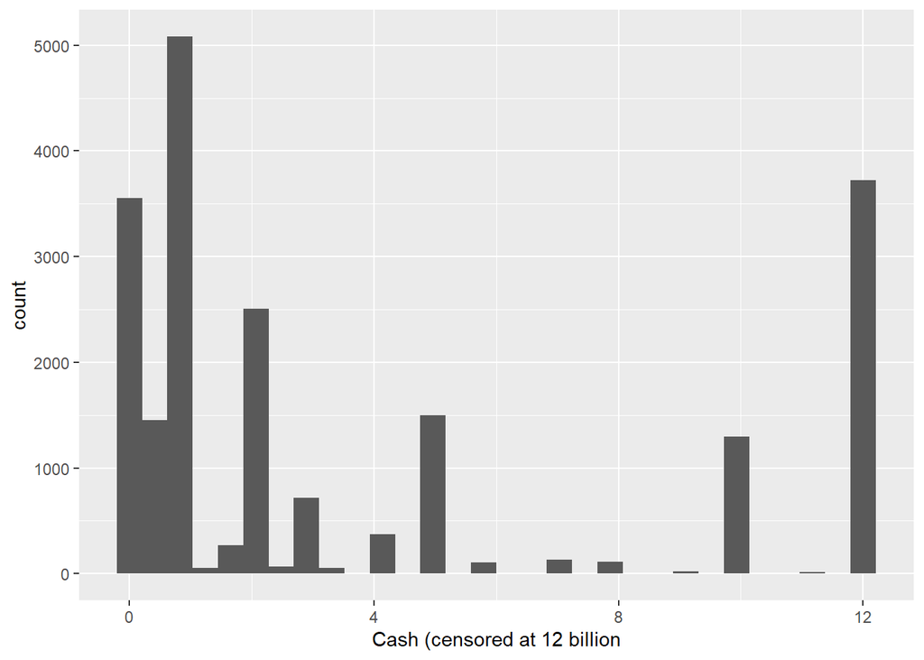

```r
cash_histogram <-
  df %>% mutate(coarsened_cash = ifelse(cash_billions > 12, 12, cash_billions)) %>% ggplot(aes(coarsened_cash)) + geom_histogram() +
  xlab("Cash (censored at 12 billion")

cash_histogram
```

```r
# Support sizes

amounts_d <- seq(0, 22, .5)
amounts_v <- seq(0, 200, 1)

# Figures cumulative distribution
support <- function(x = df$cash_billions, amounts = amounts_d)
  data.frame(
    amounts = amounts,
    support = sapply(amounts, function(j)
      mean(x >= j, na.rm = TRUE)))

s1 <- list(
  Low = support(
    df %>% dplyr::filter(risk_factor == "Low" & trading_factor == "Low") %>% pull(cash_billions),
    amounts = amounts_d),
  High  =  support(
    df %>% dplyr::filter(risk_factor == "High" & trading_factor == "High")%>% pull(cash_billions), amounts = amounts_d)) %>%
  bind_rows(.id = "Costs")

s2 <- list(
  Low = support(
    df %>% dplyr::filter(deal == "No deal") %>% pull(cash_billions)),
  High  =  support(
    df %>% dplyr::filter(deal == "40 give 40 bn") %>% pull(cash_billions))) %>%
  bind_rows(.id = "Mulilateralism")


s3 <- list(
  Low = support(
    df %>% dplyr::filter(risk_factor == "Low" & trading_factor == "Low") %>% pull(doses), amounts_v),
  High  =  support(
    df %>% dplyr::filter(risk_factor == "Low" & trading_factor == "High") %>% pull(doses), amounts_v)) %>%
  bind_rows(.id = "Costs")

s4 <- list(
  Low = support(
    df %>% dplyr::filter(deal == "No deal") %>% pull(doses), amounts_v),
  High  =  support(
    df %>% dplyr::filter(deal == "40 give 40 bn") %>% pull(doses), amounts_v)) %>%
  bind_rows(.id = "Mulilateralism")


supports <- ggarrange(

s1 %>% ggplot(aes(amounts, support, color = Costs)) + geom_line() + ylim(0,1) + theme_bw() + xlab("German contribution (bn Euro)") + ylab("Share supporting")  + theme(legend.position="bottom"),

s2 %>% ggplot(aes(amounts, support, color = Mulilateralism)) + geom_line() + ylim(0,1) + theme_bw() + xlab("German contribution (bn  Euro)") + ylab("Share supporting")   + theme(legend.position="bottom") + ylab(""),

s3 %>% ggplot(aes(amounts, support, color = Costs)) + geom_line() + ylim(0,1) + theme_bw() + xlab("German contribution (mio vaccines)") + ylab("Share supporting")  + theme(legend.position="bottom"),

s4 %>% ggplot(aes(amounts, support, color = Mulilateralism)) + geom_line() + ylim(0,1) + theme_bw() + xlab("German contribution (mio vaccines)") + ylab("Share supporting")   + theme(legend.position="bottom") + ylab(""),

nrow = 2, ncol = 2)

pdf("2_output/cumulative.pdf", height = 6, width = 10)
 supports
dev.off()
```

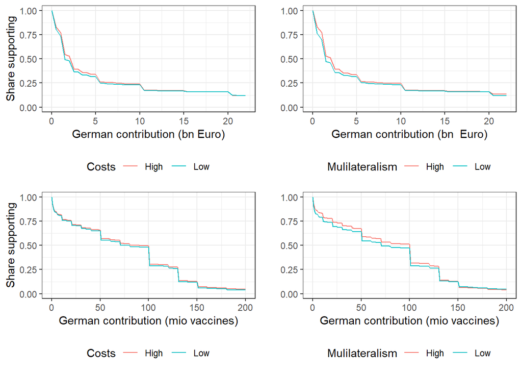

```r
supports
```

## 4.2 Supports by party, by migration attitude

```r
sp <- lapply(unique(df$party), function(p)
support(
    df %>% dplyr::filter(party == p) %>% pull(cash_billions),
    amounts = amounts_d))
names(sp) <- unique(df$party)

sp <- sp %>% bind_rows(.id = "Party")

supports_by_party <-
  sp %>% ggplot(aes(amounts, support, color = Party)) + geom_line() + ylim(0,1) + theme_bw() + xlab("German contribution (bn Euro)") + ylab("Share supporting")  + theme(legend.position="bottom")

pdf("2_output/cumulative_by_party.pdf", height = 6, width = 10)
 supports_by_party
dev.off()
```

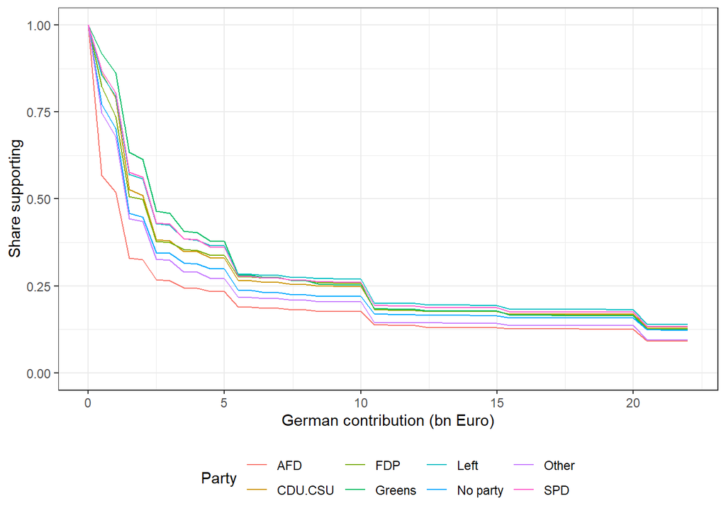

```r
supports_by_party
```

```r
sm <- lapply(0:1, function(m)
support(
    df %>% dplyr::filter(migration_background == m) %>% pull(cash_billions),
    amounts = amounts_d))
names(sm) <- c("Non migrant", "Migrant")

sm <- sm %>% bind_rows(.id = "Migration_background")

supports_by_migration <-
  sm %>% ggplot(aes(amounts, support, color = Migration_background)) + geom_line() + ylim(0,1) + theme_bw() + xlab("German contribution (bn Euro)") + ylab("Share supporting")  + theme(legend.position="bottom")

pdf("2_output/cumulative_by_migration.pdf", height = 6, width = 10)
 supports_by_migration
dev.off()
```

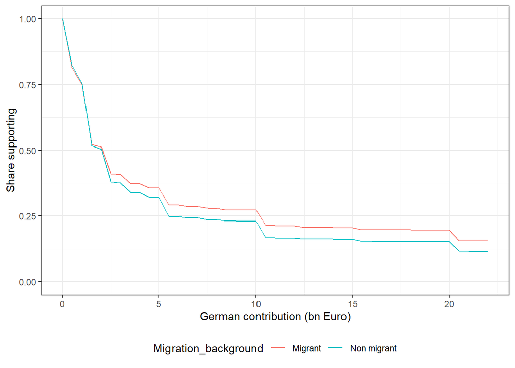

```r
supports_by_migration
```

```r
raw  <-
  df %>%
  mutate(costs = ((risk_factor == "High") + 2*(trading_factor=="High"))) %>%
  group_by(trading_factor, risk, deal, costs) %>%
  summarize(cash_bn = median(cash_billions, na.rm = TRUE),
            doses = median(doses, na.rm = TRUE))  %>%
  gather("outcome","value",  -risk,  -deal, -trading_factor, -costs)

medians_plot <-
raw %>% ggplot(aes(risk, value, color = trading_factor)) +
  facet_grid(outcome ~ deal, scales = "free_y") + geom_point()  + geom_line() + ylim(c(0, NA)) + theme_bw() + ylab(" ")+
  scale_x_continuous(breaks=c(-.45,.45), labels = c("Low", "High"))

pdf("2_output/medians.pdf", height = 5, width = 8)
 medians_plot
dev.off()
```

[figure not shown]

```r
# Note: use bootstrapping to add standard errors on the median?



observation_plot <- function(data = df)
data %>% dplyr::select(risk_factor, deal, trading_factor, cash_billions, doses, vaccinated) %>%
  mutate(cash_billions = ifelse(cash_billions>20, 20, cash_billions)) %>%
  gather("outcome","value",  -risk_factor,  -deal, -trading_factor, - vaccinated) %>%
  mutate(outcome = factor(outcome, c("cash_billions", "doses"), c("Billion Euros", "Million doses"))) %>%
  ggplot(aes(risk_factor, value, color = trading_factor)) + facet_grid(outcome ~ deal, scales = "free_y") + geom_boxplot() + ylim(c(0, NA)) + theme_bw() +
  scale_y_continuous(trans='sqrt') + ylab(" ") + xlab("Mutation risk")


observation_plot()
```

Basic variation by vaccination status

```r
df %>% group_by(vaccinated) %>%
  summarize(median_cash = median(cash_billions),
            mean_cash = mean(cash_billions),
            median_doses = median(doses),
            mean_doses = mean(doses),
            )
```

```
# A tibble: 2 x 5
  vaccinated median_cash mean_cash median_doses mean_doses
       <dbl>       <dbl>     <dbl>        <dbl>      <dbl>
1          0           1      8.39           50       64.9
2          1           2      8.72          100       80.5
```

```r
main_results <-
  list(
  cash = lm_robust(cash_billions ~ trading_importance*risk*others_number_norm*others_giving_norm  + round, fixed_effects = ~id,  se_type = "stata", data = df) %>% tidy,
  doses = lm_robust(doses ~ trading_importance*risk*others_number_norm*others_giving_norm  + round, fixed_effects = ~id,  se_type = "stata", data = df) %>% tidy) %>% bind_rows()


 treatments <- c("trading_importance", "risk", "others_number", "others_giving")
 treatments_norm <- c("trading_importance", "risk", "others_number_norm", "others_giving_norm")

 treatment_labels <- c("Trading importance", "Risk", "Number of others giving (10s)", "Amount given by others\n(10s of billions)")

df %>% group_by(risk_factor) %>% summarize(
  mean_c = mean(cash_billions),
  median_c = median(cash_billions),
  mean_d = mean(doses),
  median_d = median(doses))
```

```
# A tibble: 2 x 5
  risk_factor mean_c median_c mean_d median_d
  <fct>        <dbl>    <dbl>  <dbl>    <dbl>
1 Low           8.35     1.15   76.1       80
2 High          8.99     2      79.9      100
```

```r
#
```

# 5 Descriptives

The median proposal is: 2 billion Euros and 90 million doses.

These are close to actual https://www.auswaertiges-amt.de/en/aussenpolitik/themen/gesundheit/covax/2396914.

The median in risk conditions is proposal is: 2 billion Euros and 100 million doses.

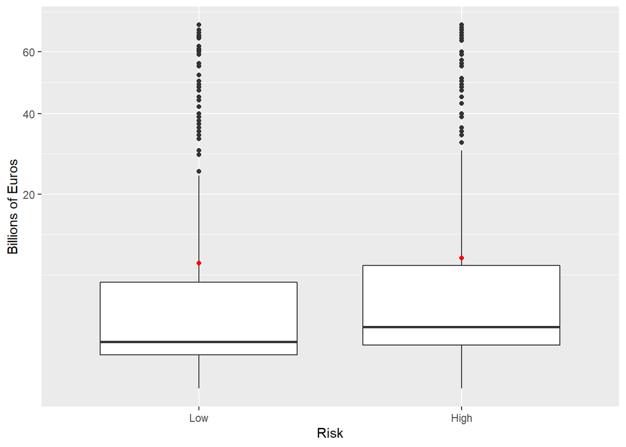

```r
figure_1 <-

  main_results %>%
  dplyr::filter(term %in% treatments_norm) %>%
  mutate(Treatment = factor(term, treatments_norm, treatment_labels),
         outcome = factor(outcome, c("cash_billions", "doses"), c("Cash (billion Euros)", "Doses (Millions)"))) %>%

  ggplot(aes(estimate, Treatment)) + geom_point()+
  geom_errorbar(aes(xmin = conf.low, xmax = conf.high), width = .1)+
  geom_vline(xintercept=0, linetype="longdash", lwd=0.35, colour = "#B55555") +
  theme_bw() + facet_grid(~outcome, scales = "free_x")+
  ylab("")


df_mean <- df %>%
  group_by(risk_factor) %>%
  summarize(average = mean(cash_billions, na.rm = TRUE)) %>%
  ungroup()

figure_2 <-
  df %>%
  ggplot(aes(risk_factor, cash_billions)) +
  geom_boxplot() + ylab("Billions of Euros")   + xlab("Risk")  + scale_y_sqrt() +
  geom_point(data = df_mean,
             mapping = aes(x = risk_factor, y = average),
             color="red")

figure_3 <-
  df %>%
  ggplot(aes(risk_factor, doses)) +
  geom_boxplot() + ylab("Millions of doses") + xlab("Risk")

figure_2
```

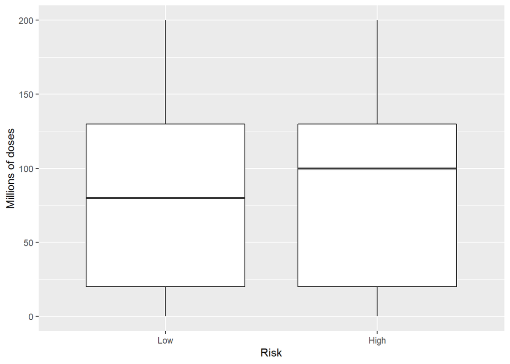

```r
figure_3
```

Note that the doses options was limited to between 0 and 200 m.

Offers are responsive to risk and economic impacts but not much to coordination considerations.

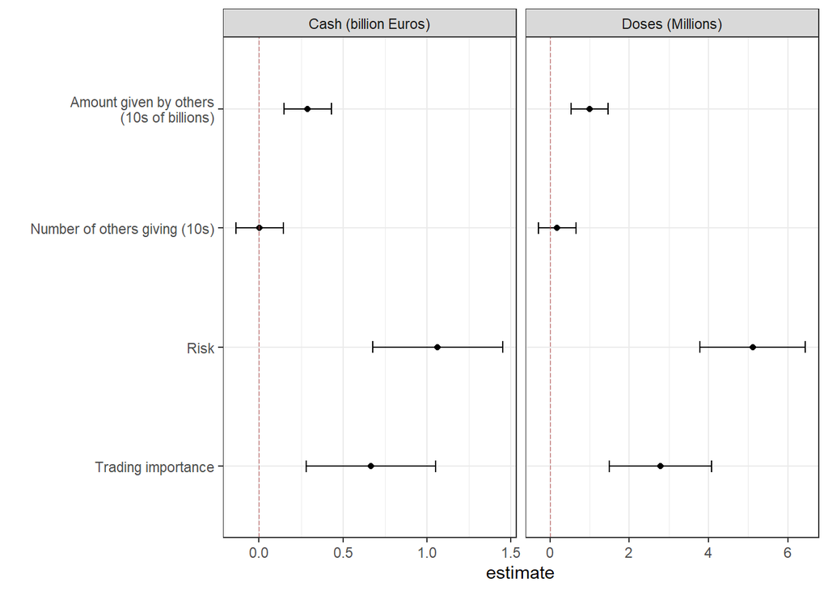

```r
figure_1
```

```r
pdf("2_output/E1_main.pdf", width = 6, height = 3)
figure_1
dev.off()
```

Trading importance and risk are substitutes for cash but not doses.

Without demeaning:

```r
lm_robust(cash_billions ~ trading_factor*risk_factor+ round, fixed_effects = ~id,  se_type = "stata", data = df) %>% tidy  %>%
  kbl(digit =2) %>%
  kable_minimal()
```

| term | estimate | std.error | statistic | p.value | conf.low | conf.high | df | outcome |
| --- | --- | --- | --- | --- | --- | --- | --- | --- |
| trading_factorHigh | 0.83 | 0.23 | 3.54 | 0.00 | 0.37 | 1.29 | 10521 | cash_billions |
| risk_factorHigh | 1.64 | 0.24 | 6.94 | 0.00 | 1.18 | 2.11 | 10521 | cash_billions |
| round | 0.01 | 0.12 | 0.10 | 0.92 | -0.22 | 0.24 | 10521 | cash_billions |
| trading_factorHigh:risk_factorHigh | -0.65 | 0.32 | -2.01 | 0.04 | -1.28 | -0.02 | 10521 | cash_billions |

Logging helps and substitution not as strong:

```r
lm_robust(log(cash_billions+1) ~ trading_factor*risk_factor+ round, fixed_effects = ~id,  se_type = "stata", data = df) %>% tidy  %>%
  kbl(digit =2) %>%
  kable_minimal()
```

| term | estimate | std.error | statistic | p.value | conf.low | conf.high | df | outcome |
| --- | --- | --- | --- | --- | --- | --- | --- | --- |
| trading_factorHigh | 0.10 | 0.01 | 6.76 | 0.00 | 0.07 | 0.13 | 10521 | log(cash_billions + 1) |
| risk_factorHigh | 0.16 | 0.01 | 10.80 | 0.00 | 0.13 | 0.19 | 10521 | log(cash_billions + 1) |
| round | 0.02 | 0.01 | 2.10 | 0.04 | 0.00 | 0.03 | 10521 | log(cash_billions + 1) |
| trading_factorHigh:risk_factorHigh | -0.05 | 0.02 | -2.34 | 0.02 | -0.09 | -0.01 | 10521 | log(cash_billions + 1) |

## 5.1 Full results from saturated models

```r
main_results %>%
  kbl(digit =2) %>%
  kable_minimal()
```

| term | estimate | std.error | statistic | p.value | conf.low | conf.high | df | outcome |
| --- | --- | --- | --- | --- | --- | --- | --- | --- |
| trading_importance | 0.67 | 0.20 | 3.38 | 0.00 | 0.28 | 1.05 | 10509 | cash_billions |
| risk | 1.06 | 0.20 | 5.37 | 0.00 | 0.68 | 1.45 | 10509 | cash_billions |
| others_number_norm | 0.00 | 0.07 | 0.05 | 0.96 | -0.14 | 0.14 | 10509 | cash_billions |
| others_giving_norm | 0.29 | 0.07 | 4.01 | 0.00 | 0.15 | 0.43 | 10509 | cash_billions |
| round | 0.02 | 0.12 | 0.17 | 0.86 | -0.21 | 0.25 | 10509 | cash_billions |
| trading_importance:risk | -0.23 | 0.39 | -0.60 | 0.55 | -1.00 | 0.53 | 10509 | cash_billions |
| trading_importance:others_number_norm | 0.03 | 0.15 | 0.19 | 0.85 | -0.26 | 0.32 | 10509 | cash_billions |
| risk:others_number_norm | 0.05 | 0.14 | 0.35 | 0.73 | -0.23 | 0.33 | 10509 | cash_billions |
| trading_importance:others_giving_norm | -0.03 | 0.15 | -0.24 | 0.81 | -0.32 | 0.25 | 10509 | cash_billions |
| risk:others_giving_norm | -0.04 | 0.15 | -0.24 | 0.81 | -0.33 | 0.26 | 10509 | cash_billions |
| others_number_norm:others_giving_norm | -0.02 | 0.04 | -0.43 | 0.67 | -0.11 | 0.07 | 10509 | cash_billions |
| trading_importance:risk:others_number_norm | -0.30 | 0.28 | -1.08 | 0.28 | -0.86 | 0.25 | 10509 | cash_billions |
| trading_importance:risk:others_giving_norm | -0.02 | 0.30 | -0.06 | 0.95 | -0.60 | 0.56 | 10509 | cash_billions |
| trading_importance:others_number_norm:others_giving_norm | -0.12 | 0.08 | -1.38 | 0.17 | -0.28 | 0.05 | 10509 | cash_billions |
| risk:others_number_norm:others_giving_norm | 0.17 | 0.09 | 2.04 | 0.04 | 0.01 | 0.34 | 10509 | cash_billions |
| trading_importance:risk:others_number_norm:others_giving_norm | -0.29 | 0.17 | -1.68 | 0.09 | -0.62 | 0.05 | 10509 | cash_billions |
| trading_importance | 2.78 | 0.66 | 4.24 | 0.00 | 1.50 | 4.07 | 10509 | doses |
| risk | 5.11 | 0.68 | 7.52 | 0.00 | 3.78 | 6.44 | 10509 | doses |
| others_number_norm | 0.18 | 0.24 | 0.76 | 0.45 | -0.29 | 0.65 | 10509 | doses |
| others_giving_norm | 1.00 | 0.24 | 4.22 | 0.00 | 0.53 | 1.46 | 10509 | doses |
| round | 1.80 | 0.38 | 4.72 | 0.00 | 1.05 | 2.55 | 10509 | doses |
| trading_importance:risk | -0.67 | 1.24 | -0.54 | 0.59 | -3.10 | 1.76 | 10509 | doses |
| trading_importance:others_number_norm | 0.30 | 0.48 | 0.63 | 0.53 | -0.64 | 1.24 | 10509 | doses |
| risk:others_number_norm | 0.48 | 0.48 | 1.02 | 0.31 | -0.45 | 1.42 | 10509 | doses |
| trading_importance:others_giving_norm | 0.01 | 0.47 | 0.02 | 0.99 | -0.92 | 0.93 | 10509 | doses |
| risk:others_giving_norm | -0.58 | 0.48 | -1.20 | 0.23 | -1.51 | 0.36 | 10509 | doses |
| others_number_norm:others_giving_norm | -0.38 | 0.14 | -2.68 | 0.01 | -0.65 | -0.10 | 10509 | doses |
| trading_importance:risk:others_number_norm | 0.09 | 0.95 | 0.09 | 0.93 | -1.78 | 1.96 | 10509 | doses |
| trading_importance:risk:others_giving_norm | 0.34 | 0.97 | 0.35 | 0.73 | -1.56 | 2.23 | 10509 | doses |
| trading_importance:others_number_norm:others_giving_norm | -0.24 | 0.27 | -0.91 | 0.37 | -0.77 | 0.28 | 10509 | doses |
| risk:others_number_norm:others_giving_norm | 0.36 | 0.28 | 1.28 | 0.20 | -0.19 | 0.92 | 10509 | doses |
| trading_importance:risk:others_number_norm:others_giving_norm | -0.85 | 0.54 | -1.57 | 0.12 | -1.91 | 0.21 | 10509 | doses |

## 5.2 Main results by subgroup

```r
main_results_by_party <-
  lapply(unique(df$party), function(p)
    list(
      cash = lm_robust(cash_billions ~ trading_importance*risk*others_number_norm*others_giving_norm  + round,
                       fixed_effects = ~id,  se_type = "stata",
                       data = df %>% dplyr::filter(party == p)) %>% tidy,
      doses = lm_robust(doses ~ trading_importance*risk*others_number_norm*others_giving_norm  + round,
                        fixed_effects = ~id,  se_type = "stata",
                        data = df %>% dplyr::filter(party == p)) %>% tidy) %>%
      bind_rows() %>% mutate(party = p)) %>%
  bind_rows()

figure_1_party <-

  main_results_by_party %>%
  dplyr::filter(term %in% treatments_norm) %>%
  mutate(Treatment = factor(term, treatments_norm, treatment_labels),
         outcome = factor(outcome, c("cash_billions", "doses"), c("Cash (billion Euros)", "Doses (Millions)"))) %>%

  ggplot(aes(Treatment, estimate, color = party)) +
  geom_point(position = position_dodge(0.3))+
  geom_errorbar(aes(ymin = conf.low, ymax = conf.high), position = position_dodge(0.3), width = .1)+
  geom_hline(yintercept=0, linetype="longdash", lwd=0.35, colour = "#B55555") +
  theme_bw() + facet_grid(~outcome, scales = "free_x")+
  xlab("") +
  coord_flip()

pdf("2_output/figure_1_party.pdf", width = 9, height = 7)
 figure_1_party
dev.off()
```

```r
main_results_by_background <-
  lapply(unique(df$migration_background), function(p)
    list(
      cash = lm_robust(cash_billions ~ trading_importance*risk*others_number_norm*others_giving_norm  + round,
                       fixed_effects = ~id,  se_type = "stata",
                       data = df %>% dplyr::filter(migration_background == p)) %>% tidy,
      doses = lm_robust(doses ~ trading_importance*risk*others_number_norm*others_giving_norm  + round,
                        fixed_effects = ~id,  se_type = "stata",
                        data = df %>% dplyr::filter(migration_background == p)) %>% tidy) %>%
      bind_rows() %>% mutate(migration_background = factor(p))) %>%
  bind_rows()

figure_1_background <-

  main_results_by_background %>%
  dplyr::filter(term %in% treatments_norm) %>%
  mutate(Treatment = factor(term, treatments_norm, treatment_labels),
         outcome = factor(outcome, c("cash_billions", "doses"), c("Cash (billion Euros)", "Doses (Millions)"))) %>%

  ggplot(aes(Treatment, estimate, color = migration_background)) +
  geom_point(position = position_dodge(0.3))+
  geom_errorbar(aes(ymin = conf.low, ymax = conf.high), position = position_dodge(0.3), width = .1)+
  geom_hline(yintercept=0, linetype="longdash", lwd=0.35, colour = "#B55555") +
  theme_bw() + facet_grid(~outcome, scales = "free_x")+
  xlab("") +
  coord_flip()

pdf("2_output/figure_1_background.pdf", width = 9, height = 4)
 figure_1_background
dev.off()
```

## 5.3 Video experiment

```r
outcomes <- c("solidarity_behaviour", "solidarity_attitude")
outcome_labels <- c("Solidarity Bahaviour", "Solidarity Attitude")
w2_treatments <- c("treatment_video")
w2_treatment_labels <- c("Treatment")
```

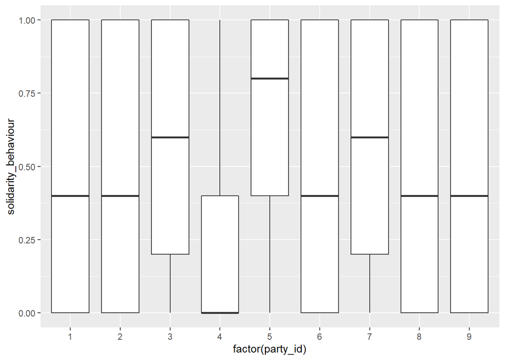

```r
#r, child = "2_main_results.Rmd", eval = TRUE}
# put in separate files later

df_2 <- dplyr::filter(main_df, wave == 2)


# df_2$solidarity_bahaviour %>%
#  hist(main = "Distribution of allocations from behavioral measure")

df_2 %>%
  ggplot(aes(factor(party_id), solidarity_behaviour)) + geom_boxplot()
```

```r
  ggtitle("Distribution of allocations from behavioral measure")
```

$title [1] “Distribution of allocations from behavioral measure”

attr(,“class”) [1] “labels”

```r
stargazer::stargazer(
  lm(solidarity_behaviour ~ treatment_video, data = df_2),
  lm(solidarity_attitude ~ treatment_video, data = df_2),
  header = FALSE, type = "latex")
```

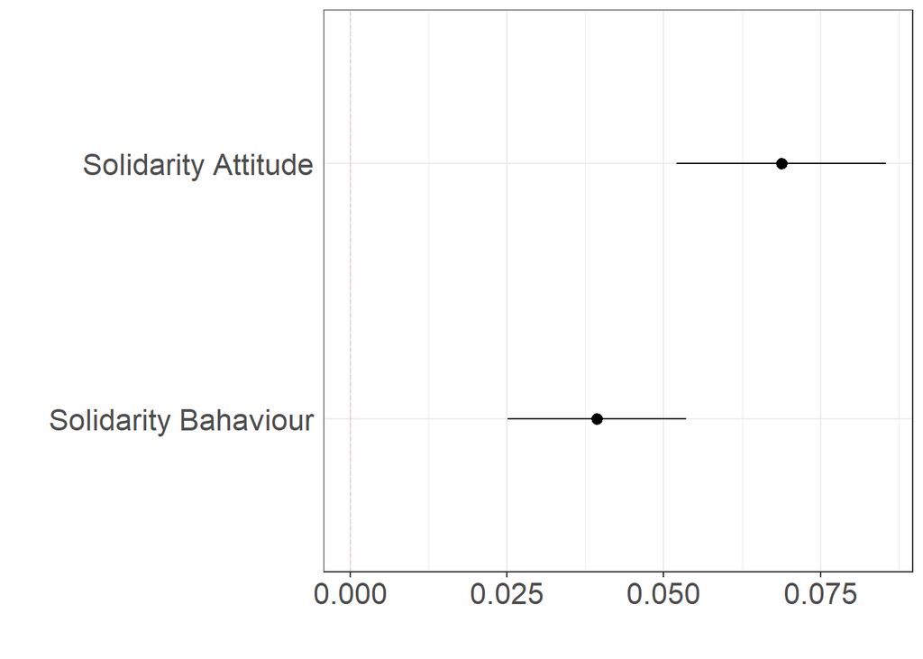

```r
models_basic <- lapply(c(outcomes), function(y)
lm_robust(as.formula(paste(y, "~",   paste(w2_treatments, collapse =  "+"))), data = df_2))
names(models_basic) <- outcomes


figure_video <-
  lapply(models_basic, tidy) %>% bind_rows(.id = "outcome") %>%
  dplyr::filter(term != "(Intercept)") %>%
  mutate(outcome = factor(outcome, outcomes, outcome_labels)) %>%
  ggplot(aes(estimate, outcome)) + geom_point() +
  #facet_grid(~outcome) +
  geom_pointrange(aes(xmin = conf.low, xmax = conf.high),
                  position = position_dodge(width = 0.3), width = .1)+
  theme_bw()+
  #ylab("Change in support for regime (0-1)") +
    geom_vline(xintercept=0, linetype="longdash",
               lwd=0.35, size=0.75,alpha=0.3, colour = "#B55555")  +
    xlab("") + ylab("")  +
    theme(#panel.grid.major = element_blank(),
          #panel.grid.minor = element_blank(),
          #panel.background = element_blank(),
          #strip.background = element_blank(),
          # strip.text.y = element_blank(),
          #axis.text.y=element_blank(),
          legend.position = "top",
          text = element_text(size=20),
          legend.title=element_blank(),
          strip.text.y = element_text(angle = 180),
          axis.ticks.y=element_blank()) +
    scale_color_grey()


figure_video
```

## 5.4 Longer term follow up

```r
table(df$ID %in% df_2$ID)
```

```
FALSE  TRUE
 4250 16800
```

```r
df <- left_join(df, df_2 %>% dplyr::select(ID, treatment_video))

lm_robust(log(cash_billions+1) ~ trading_factor*risk_factor+ treatment_video + round,  se_type = "stata", data = df) %>% tidy  %>%
  kbl(digit =2) %>%
  kable_minimal()
```

| term | estimate | std.error | statistic | p.value | conf.low | conf.high | df | outcome |
| --- | --- | --- | --- | --- | --- | --- | --- | --- |
| (Intercept) | 1.28 | 0.03 | 36.90 | 0.00 | 1.21 | 1.35 | 16794 | log(cash_billions + 1) |
| trading_factorHigh | 0.01 | 0.03 | 0.46 | 0.65 | -0.04 | 0.06 | 16794 | log(cash_billions + 1) |
| risk_factorHigh | 0.10 | 0.03 | 3.62 | 0.00 | 0.04 | 0.15 | 16794 | log(cash_billions + 1) |
| treatment_video | 0.01 | 0.02 | 0.63 | 0.53 | -0.02 | 0.05 | 16794 | log(cash_billions + 1) |
| round | 0.02 | 0.02 | 0.82 | 0.41 | -0.02 | 0.05 | 16794 | log(cash_billions + 1) |
| trading_factorHigh:risk_factorHigh | -0.04 | 0.04 | -1.03 | 0.30 | -0.11 | 0.03 | 16794 | log(cash_billions + 1) |

```r
lm_robust(cash_billions ~ trading_factor + risk_factor*treatment_video,  se_type = "stata", data = df) %>% tidy  %>%
  kbl(digit =2) %>%
  kable_minimal()
```

| term | estimate | std.error | statistic | p.value | conf.low | conf.high | df | outcome |
| --- | --- | --- | --- | --- | --- | --- | --- | --- |
| (Intercept) | 8.18 | 0.26 | 31.13 | 0.00 | 7.67 | 8.70 | 16795 | cash_billions |
| trading_factorHigh | -0.39 | 0.24 | -1.61 | 0.11 | -0.86 | 0.09 | 16795 | cash_billions |
| risk_factorHigh | 0.68 | 0.34 | 2.01 | 0.04 | 0.02 | 1.35 | 16795 | cash_billions |
| treatment_video | 0.02 | 0.33 | 0.06 | 0.95 | -0.63 | 0.67 | 16795 | cash_billions |
| risk_factorHigh:treatment_video | 0.12 | 0.48 | 0.25 | 0.80 | -0.82 | 1.07 | 16795 | cash_billions |

# 6 Individual solidarity

Should an older Indian woman be prioritized over a young German?

```r
## Prioritization analysis

main_df <- main_df %>% mutate(
    de_de_preference  = perspective_fed_german - perspective_fed_indian # DE Preference for German 25
#    who_de_preference  = perspective_who_german - perspective_who_indian # WHO Preference for German 25
)

main_df %>% group_by(wave) %>%
  summarize(
    priority_de_indian = mean(perspective_fed_indian),
    priority_de_german = mean(perspective_fed_german),
 #   priority_who_indian = mean(perspective_who_indian),
#    priority_who_german = mean(perspective_who_german),
    de_ind_preference  = mean(perspective_fed_german <= perspective_fed_indian),
    de_ind_preference2  = mean(perspective_fed_german < perspective_fed_indian),
    de_ind_preference3  = mean(perspective_fed_german == perspective_fed_indian),
 #   who = mean(who_de_preference, na.rm = TRUE),
 #   who_priority = mean(who_de_preference>0, na.rm = TRUE)
    ) %>% t %>% kable()
```

| wave | 1 | 2.0000000 | 3 | 4.0000000 |
| --- | --- | --- | --- | --- |
| priority_de_indian | NA | 4.4939777 | NA | 4.3994578 |
| priority_de_german | NA | 4.2369758 | NA | 4.6793494 |
| de_ind_preference | NA | 0.6229139 | NA | 0.5700664 |
| de_ind_preference2 | NA | 0.4590771 | NA | 0.3837525 |
| de_ind_preference3 | NA | 0.1638369 | NA | 0.1863139 |

```r
# about 57% of Germans think that a German 25 year old should be at least as high a priority as an Indian 65 year old
#  22% think the same for WHO priortization

M <- lm_robust(cash_billions_log ~  perspective_fed_german + perspective_fed_indian, data = df)
M %>% tidy %>% kable(digits = 2)
```

| term | estimate | std.error | statistic | p.value | conf.low | conf.high | df | outcome |
| --- | --- | --- | --- | --- | --- | --- | --- | --- |
| (Intercept) | 0.89 | 0.04 | 20.45 | 0 | 0.81 | 0.98 | 21047 | cash_billions_log |
| perspective_fed_german | 0.02 | 0.01 | 4.10 | 0 | 0.01 | 0.03 | 21047 | cash_billions_log |
| perspective_fed_indian | 0.09 | 0.01 | 16.57 | 0 | 0.08 | 0.10 | 21047 | cash_billions_log |

```r
# M$r.squared

# plot(df$cash_billions_log, df$perspective_fed_indian)
```

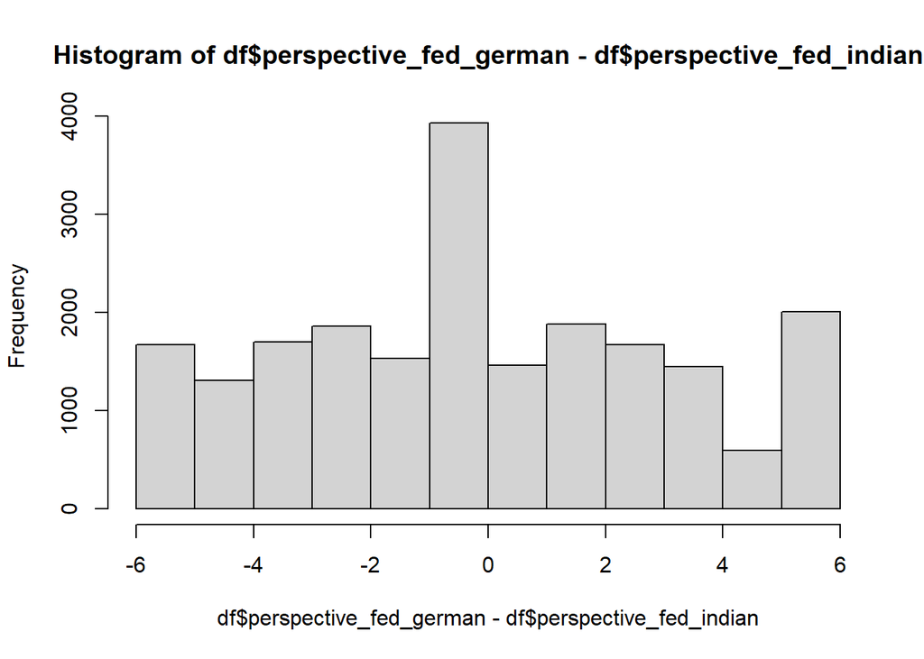

```r
hist(df$perspective_fed_german - df$perspective_fed_indian)
```

```r
lm_robust(log(cash_billions+1) ~ trading_factor*risk_factor+ treatment_video + round + perspective_fed_german +perspective_fed_indian,  se_type = "stata", data = df) %>% tidy  %>%
  kbl(digit =2) %>%
  kable_minimal()
```

| term | estimate | std.error | statistic | p.value | conf.low | conf.high | df | outcome |
| --- | --- | --- | --- | --- | --- | --- | --- | --- |
| (Intercept) | 0.84 | 0.06 | 14.26 | 0.00 | 0.72 | 0.95 | 16792 | log(cash_billions + 1) |
| trading_factorHigh | 0.01 | 0.03 | 0.58 | 0.56 | -0.04 | 0.07 | 16792 | log(cash_billions + 1) |
| risk_factorHigh | 0.09 | 0.03 | 3.57 | 0.00 | 0.04 | 0.15 | 16792 | log(cash_billions + 1) |
| treatment_video | 0.01 | 0.02 | 0.30 | 0.76 | -0.03 | 0.04 | 16792 | log(cash_billions + 1) |
| round | 0.02 | 0.02 | 0.83 | 0.41 | -0.02 | 0.05 | 16792 | log(cash_billions + 1) |
| perspective_fed_german | 0.02 | 0.01 | 2.98 | 0.00 | 0.01 | 0.03 | 16792 | log(cash_billions + 1) |
| perspective_fed_indian | 0.08 | 0.01 | 14.30 | 0.00 | 0.07 | 0.09 | 16792 | log(cash_billions + 1) |
| trading_factorHigh:risk_factorHigh | -0.04 | 0.04 | -1.12 | 0.26 | -0.11 | 0.03 | 16792 | log(cash_billions + 1) |

# 7 Wave 2 conjoint

```r
label <- "1_input/W2_exp3_vignettes_universe.dta" %>%
  read_dta() %>%
    mutate(vignr = as.numeric(vignr))


label$vig_doses %>% table()
```

. 0 1 2 3 48 48 48 48

```r
conjoints <-

  list(
    conjoint1_1 =
      df_2 %>%
      mutate(vignr = as.numeric(c_0031_w2),
             outcome = conjoint_choice1_exp3, rating = conjoint_rating1_exp3, contest = 1, candidate=1) %>%
      select(ID, vignr, outcome, rating, contest, candidate),

  conjoint1_2 =
      df_2 %>%
      mutate(vignr = as.numeric(c_0032_w2),
             outcome = conjoint_choice1_exp3, rating = conjoint_rating2_exp3, contest = 1, candidate=2) %>%
      select(ID, vignr, outcome, rating, contest, candidate),


  conjoint2_1 =
      df_2 %>%
      mutate(vignr = as.numeric(vignette3),
             outcome = conjoint_choice2_exp3, rating = conjoint_rating3_exp3, contest = 2, candidate=1) %>%
      select(ID, vignr, outcome, rating, contest, candidate),


    conjoint2_2 =
      df_2 %>%
      mutate(vignr = as.numeric(vignette4),
             outcome = conjoint_choice2_exp3, rating = conjoint_rating4_exp3, contest = 2, candidate=2) %>%
      select(ID, vignr, outcome, rating, contest, candidate),


                conjoint3_1 =
      df_2 %>%
      mutate(vignr = as.numeric(vignette5),
             outcome = conjoint_choice3_exp3, rating = conjoint_rating5_exp3, contest = 3, candidate=1) %>%
      select(ID, vignr, outcome, rating, contest, candidate),


                    conjoint3_2 =
      df_2 %>%
      mutate(vignr = as.numeric(vignette6),
             outcome = conjoint_choice3_exp3,
             rating = conjoint_rating6_exp3, contest = 3, candidate=2) %>%
      select(ID, vignr, outcome, rating, contest, candidate)

) %>% bind_rows() %>%
  mutate(outcome = ifelse(candidate ==1, as.numeric(outcome=="1"), as.numeric(outcome=="2"))) %>%
  left_join(label) %>%
  mutate(
    doses = factor(
      vig_doses, 0:3,
      c("1 Million doses", "5 Million doses", "10 Million doses", "20 Million doses")),
    share = factor(vig_dose_share, 0:3,
      c("1 % of the vaccines", "5 % of the vaccines", "10 % of the vaccines", "20 % of the vaccines")),
    number= factor(vig_countries, 0:2, c("20 countries", "80 countries", "160 countries")),
    economic_benefits= factor(vig_benefit_economic, 0:1, c("Without economic importance", "With economic importance")),
    health_benefits=factor(vig_benefit_health, 0:1,
      c("No risk of infection", "Risk of infection"))) %>%
  left_join(df_2 %>% dplyr::select(ID, treatment_video))

# Normalizae data
# Note that mean rating is removed
conjoints_norm <- conjoints %>%
  mutate(doses_norm = vig_doses - mean(vig_doses),
         number_norm = vig_countries - mean(vig_countries),
         share_norm = vig_dose_share - mean(vig_dose_share),
         economic_benefits = vig_benefit_economic - mean(vig_benefit_economic),
         health_benefits = vig_benefit_health - mean(vig_benefit_health)) %>%
  group_by(ID) %>% mutate(rating = rating - mean(rating)) %>% ungroup %>%
  left_join(df_2 %>% dplyr::select(ID, treatment_video))


models_interactions <-
  list(
    rating0 = lm_robust(rating ~  doses_norm*share_norm*number_norm*economic_benefits*health_benefits, data = conjoints_norm),
    rating1 = lm_robust(rating ~  doses_norm*share_norm*number_norm*economic_benefits*health_benefits, data = conjoints_norm),
    choice0 = lm_robust(outcome ~  doses_norm*share_norm*number_norm*economic_benefits*health_benefits, data = conjoints_norm),
    choice1 = lm_robust(outcome ~  doses_norm*share_norm*number_norm*economic_benefits*health_benefits, data = conjoints_norm)
  )


models_treatments <-
  list(
    rating = lm_robust(rating ~  treatment_video*vig_doses + treatment_video*vig_dose_share + treatment_video*vig_countries + treatment_video*vig_benefit_economic + treatment_video*vig_benefit_health,
                        data = conjoints_norm),
    choice = lm_robust(outcome ~  treatment_video*vig_doses + treatment_video*vig_dose_share + treatment_video*vig_countries + treatment_video*vig_benefit_economic + treatment_video*vig_benefit_health,
                        data = conjoints_norm)
    )

htmlreg(models_interactions)
```

Statistical models

|  | rating0 | rating1 | choice0 | choice1 |
| --- | --- | --- | --- | --- |
| (Intercept) | -0.00 | -0.00 | 0.50* | 0.50* |
|  | [-0.01; 0.01] | [-0.01; 0.01] | [ 0.50; 0.50] | [ 0.50; 0.50] |
| doses_norm | -0.07* | -0.07* | -0.02* | -0.02* |
|  | [-0.08; -0.06] | [-0.08; -0.06] | [-0.02; -0.02] | [-0.02; -0.02] |
| share_norm | -0.09* | -0.09* | -0.02* | -0.02* |
|  | [-0.10; -0.08] | [-0.10; -0.08] | [-0.02; -0.02] | [-0.02; -0.02] |
| number_norm | 0.21* | 0.21* | 0.07* | 0.07* |
|  | [ 0.20; 0.23] | [ 0.20; 0.23] | [ 0.06; 0.07] | [ 0.06; 0.07] |
| economic_benefits | -0.21* | -0.21* | -0.06* | -0.06* |
|  | [-0.24; -0.19] | [-0.24; -0.19] | [-0.06; -0.05] | [-0.06; -0.05] |
| health_benefits | 0.11* | 0.11* | 0.03* | 0.03* |
|  | [ 0.08; 0.13] | [ 0.08; 0.13] | [ 0.02; 0.04] | [ 0.02; 0.04] |
| doses_norm:share_norm | -0.01 | -0.01 | -0.00 | -0.00 |
|  | [-0.02; 0.00] | [-0.02; 0.00] | [-0.01; 0.00] | [-0.01; 0.00] |
| doses_norm:number_norm | -0.01 | -0.01 | -0.00* | -0.00* |
|  | [-0.03; 0.00] | [-0.03; 0.00] | [-0.01; -0.00] | [-0.01; -0.00] |
| share_norm:number_norm | -0.00 | -0.00 | -0.00 | -0.00 |
|  | [-0.02; 0.01] | [-0.02; 0.01] | [-0.00; 0.00] | [-0.00; 0.00] |
| doses_norm:economic_benefits | -0.01 | -0.01 | -0.00 | -0.00 |
|  | [-0.04; 0.01] | [-0.04; 0.01] | [-0.01; 0.00] | [-0.01; 0.00] |
| share_norm:economic_benefits | 0.02 | 0.02 | 0.00 | 0.00 |
|  | [-0.00; 0.05] | [-0.00; 0.05] | [-0.00; 0.01] | [-0.00; 0.01] |
| number_norm:economic_benefits | -0.01 | -0.01 | -0.01 | -0.01 |
|  | [-0.04; 0.03] | [-0.04; 0.03] | [-0.02; 0.00] | [-0.02; 0.00] |
| doses_norm:health_benefits | 0.00 | 0.00 | 0.00 | 0.00 |
|  | [-0.02; 0.03] | [-0.02; 0.03] | [-0.00; 0.01] | [-0.00; 0.01] |
| share_norm:health_benefits | -0.01 | -0.01 | -0.00 | -0.00 |
|  | [-0.03; 0.02] | [-0.03; 0.02] | [-0.01; 0.00] | [-0.01; 0.00] |
| number_norm:health_benefits | -0.00 | -0.00 | -0.01 | -0.01 |
|  | [-0.04; 0.03] | [-0.04; 0.03] | [-0.01; 0.00] | [-0.01; 0.00] |
| economic_benefits:health_benefits | 0.10* | 0.10* | 0.01 | 0.01 |
|  | [ 0.04; 0.15] | [ 0.04; 0.15] | [-0.00; 0.02] | [-0.00; 0.02] |
| doses_norm:share_norm:number_norm | -0.01 | -0.01 | -0.00 | -0.00 |
|  | [-0.03; 0.00] | [-0.03; 0.00] | [-0.01; 0.00] | [-0.01; 0.00] |
| doses_norm:share_norm:economic_benefits | -0.00 | -0.00 | 0.00 | 0.00 |
|  | [-0.02; 0.02] | [-0.02; 0.02] | [-0.00; 0.01] | [-0.00; 0.01] |
| doses_norm:number_norm:economic_benefits | -0.02 | -0.02 | -0.00 | -0.00 |
|  | [-0.05; 0.01] | [-0.05; 0.01] | [-0.01; 0.00] | [-0.01; 0.00] |
| share_norm:number_norm:economic_benefits | -0.00 | -0.00 | -0.00 | -0.00 |
|  | [-0.03; 0.03] | [-0.03; 0.03] | [-0.01; 0.00] | [-0.01; 0.00] |
| doses_norm:share_norm:health_benefits | 0.01 | 0.01 | -0.00 | -0.00 |
|  | [-0.02; 0.03] | [-0.02; 0.03] | [-0.01; 0.00] | [-0.01; 0.00] |
| doses_norm:number_norm:health_benefits | 0.02 | 0.02 | -0.00 | -0.00 |
|  | [-0.02; 0.05] | [-0.02; 0.05] | [-0.01; 0.01] | [-0.01; 0.01] |
| share_norm:number_norm:health_benefits | -0.01 | -0.01 | -0.00 | -0.00 |
|  | [-0.04; 0.02] | [-0.04; 0.02] | [-0.01; 0.01] | [-0.01; 0.01] |
| doses_norm:economic_benefits:health_benefits | -0.02 | -0.02 | 0.00 | 0.00 |
|  | [-0.07; 0.03] | [-0.07; 0.03] | [-0.01; 0.01] | [-0.01; 0.01] |
| share_norm:economic_benefits:health_benefits | -0.00 | -0.00 | -0.00 | -0.00 |
|  | [-0.05; 0.05] | [-0.05; 0.05] | [-0.02; 0.01] | [-0.02; 0.01] |
| number_norm:economic_benefits:health_benefits | 0.05 | 0.05 | 0.01 | 0.01 |
|  | [-0.02; 0.12] | [-0.02; 0.12] | [-0.01; 0.03] | [-0.01; 0.03] |
| doses_norm:share_norm:number_norm:economic_benefits | 0.01 | 0.01 | 0.00 | 0.00 |
|  | [-0.02; 0.04] | [-0.02; 0.04] | [-0.00; 0.01] | [-0.00; 0.01] |
| doses_norm:share_norm:number_norm:health_benefits | 0.01 | 0.01 | 0.00 | 0.00 |
|  | [-0.02; 0.04] | [-0.02; 0.04] | [-0.01; 0.01] | [-0.01; 0.01] |
| doses_norm:share_norm:economic_benefits:health_benefits | -0.01 | -0.01 | -0.01 | -0.01 |
|  | [-0.05; 0.04] | [-0.05; 0.04] | [-0.02; 0.01] | [-0.02; 0.01] |
| doses_norm:number_norm:economic_benefits:health_benefits | 0.05 | 0.05 | 0.01 | 0.01 |
|  | [-0.01; 0.11] | [-0.01; 0.11] | [-0.00; 0.03] | [-0.00; 0.03] |
| share_norm:number_norm:economic_benefits:health_benefits | 0.01 | 0.01 | 0.01 | 0.01 |
|  | [-0.06; 0.07] | [-0.06; 0.07] | [-0.01; 0.02] | [-0.01; 0.02] |
| doses_norm:share_norm:number_norm:economic_benefits:health_benefits | -0.04 | -0.04 | -0.01 | -0.01 |
|  | [-0.10; 0.01] | [-0.10; 0.01] | [-0.02; 0.00] | [-0.02; 0.00] |
| R<sup>2</sup> | 0.01 | 0.01 | 0.02 | 0.02 |
| Adj. R<sup>2</sup> | 0.01 | 0.01 | 0.02 | 0.02 |
| Num. obs. | 82692 | 82692 | 82692 | 82692 |
| RMSE | 2.03 | 2.03 | 0.49 | 0.49 |

* Null hypothesis value outside the confidence interval.

```r
htmlreg(models_treatments)
```

Statistical models

|  | rating | choice |
| --- | --- | --- |
| (Intercept) | 0.17* | 0.53* |
|  | [ 0.12; 0.23] | [ 0.52; 0.54] |
| treatment_video | -0.19* | -0.04* |
|  | [-0.27; -0.11] | [-0.06; -0.02] |
| vig_doses | -0.10* | -0.03* |
|  | [-0.12; -0.08] | [-0.03; -0.03] |
| vig_dose_share | -0.10* | -0.02* |
|  | [-0.11; -0.08] | [-0.03; -0.02] |
| vig_countries | 0.17* | 0.06* |
|  | [ 0.14; 0.19] | [ 0.05; 0.06] |
| vig_benefit_economic | -0.21* | -0.05* |
|  | [-0.25; -0.17] | [-0.06; -0.04] |
| vig_benefit_health | 0.13* | 0.04* |
|  | [ 0.09; 0.17] | [ 0.03; 0.05] |
| treatment_video:vig_doses | 0.06* | 0.02* |
|  | [ 0.03; 0.08] | [ 0.01; 0.03] |
| treatment_video:vig_dose_share | 0.02 | 0.00 |
|  | [-0.01; 0.04] | [-0.00; 0.01] |
| treatment_video:vig_countries | 0.10* | 0.02* |
|  | [ 0.06; 0.13] | [ 0.01; 0.03] |
| treatment_video:vig_benefit_economic | -0.01 | -0.01 |
|  | [-0.07; 0.04] | [-0.02; 0.01] |
| treatment_video:vig_benefit_health | -0.05 | -0.01* |
|  | [-0.10; 0.01] | [-0.03; -0.00] |
| R<sup>2</sup> | 0.02 | 0.02 |
| Adj. R<sup>2</sup> | 0.01 | 0.02 |
| Num. obs. | 82692 | 82692 |
| RMSE | 2.03 | 0.49 |

* Null hypothesis value outside the confidence interval.

```r
fileConn <- file("2_output/treatment_effects.tex")
writeLines(texreg(models_treatments, float.pos = "h!", include.ci = FALSE, caption = "Effects of treatment on drivers of support for agreements. ",
  custom.coef.map = list(
    "(Intercept)" = "Constant (Average rating)",
    "treatment_video" = "Video effect (given ungenerous agreement)",
    "vig_doses" = "German contribution",
    "vig_dose_share" = "German share",
"vig_countries" = "Number of donors",
"vig_benefit_economic" = "Economic benefits",
"vig_benefit_health" = "Health benefits",
"treatment_video:vig_doses" = "Video * Contribution",
"treatment_video:vig_dose_share" = "Video * Share",
"treatment_video:vig_countries" = "Video * Donors",
"treatment_video:vig_benefit_economic" = "Video * Economics",
"treatment_video:vig_benefit_health"= "Video * Health"
    ), digits = 3), fileConn)
close(fileConn)
```

## 7.1 amce

```r
amces <-
  conjoints %>%
  cj(rating ~ doses+share+number+ economic_benefits+health_benefits,
            id =~ID)

pdf("2_output/amces.pdf", width = 5, height = 4)
 plot(amces) + theme(legend.position="none")
dev.off()
```

## 7.2 Notes on Wave 2 experiment

These seem inconsistent but they really tap into different questions; they suggest preferences for small doses and suggest preferences that are not ver responsive to other conditions.

Number of states blows everything else out of the water. This is really about what types of deals does Germany want: Germans want deals to be multilateral with sharing.

Also the benefits conditions are conceptually muddled with numbers conditions. Note:

- Regressions take numbers at face value despite uneven gaps
- The economic result is weird, but returning to the question suggests this is picking need not effects

# 8 Structural Analysis

We assume:

$$u = (a + bT + cR) \log(Y + x) - x^2 - g(x - ky)^2$$

where $T$ is trading importance, $R$ is health risk, $Y$ is total amount given by others and $y$ is average amount given by others

First order condition for maximization is:

$$\frac{(a + b*T + c*R)}{ (Y + x)} - 2x - 2g*(x - k*y) = 0$$
This yields the following quadratic. We take the second solution (with positive contributions).

$$- 2(1+g)x^2- 2((1+g)Y - gky)x +(2gkyY+(a + bT + cR)) = 0$$

```r
# Quadratic solution
maxx <- function(a,b,c,g,k,ZT,ZR,ZY,Zy) {
  AA = -2*(1+g)
  BB = -2*((1+g)*ZY - g*k*Zy)
  CC = 2*g*k*Zy*ZY + a+b*ZT+c*ZR
  (-BB - (BB^2 - 4*AA*CC)^.5)/(2*AA)
}
maxx(a=1,b=1,c=1,g=1, k=1,ZT=1,ZR=1,ZY=1,Zy=1)
```

```
[1] 0.8956439
```

## 8.1 Check solution with simulated u

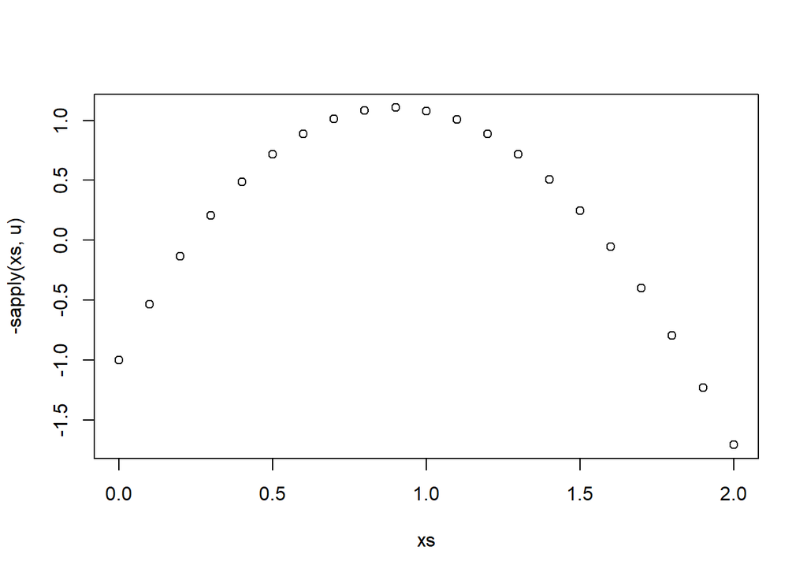

```r
# loss
u <- function(x, a=1, b=1, c=1, h=1, k=1, ZT=1, ZR=1, ZY=1, Zy=1)
  -(((a + b*ZT + c*ZR) * log(ZY + x)) - x^2 - h*(x - k*Zy)^2)

xs <- seq(0, 2, .1)
plot(xs, -sapply(xs, u))
```

maximum using quadratic solution:

```r
maxx(a=1,b=1,c=1,g=1, k=1,ZT=1,ZR=1,ZY=1,Zy=1)
```

```
[1] 0.8956439
```

matches result via `optim`:

```r
maxx_sim <- function(a,b,c,g,k,ZT,ZR,ZY,Zy)
optim(par = 2, fn = u, a=a, b=b, c=c, h = g, k = k, ZT=ZT, ZR=ZR, ZY = ZY, Zy = Zy, method = "L-BFGS-B", lower = .001)$par

maxx_sim(a=1,b=1,c=1,g=1, k=1,ZT=1,ZR=1,ZY=1,Zy=1)
```

```
[1] 0.895644
```

## 8.2 Check MLE on simulated data

```r
n <- 1000
g <- 2
sigma = 0.05

data <- df_test <-
  fabricate(N = n,
            trading_importance = simple_ra(N),
            risk = simple_ra(N),
            others_giving = 10 + 10*simple_ra(N),
            others_average = 1 + 1*simple_ra(N),
            e = rnorm(n, 0, sigma),
            x_ideal = maxx(a = 1, b = 1, c = 1, g = g, k = 1, trading_importance, risk, others_giving, others_average),
            x = x_ideal + e)


lik_x <- function(x, sigma, a,b,c,g,k,ZT,ZR,ZY,Zy)
      dnorm(x, maxx(a,b,c,g,k,ZT,ZR,ZY,Zy), sd = sigma)


# Define negative log likelihood as a function of parameters
# LL  <- function(a=1,b=1,c=1,g=1,k=1, sigma=1, data) {
#
#     R <- with(data,
#           lik_x(x,
#              sigma,
#              a, b, c, g, k,
#              ZT = trading_importance,
#              ZR = risk,
#              ZY = others_giving,
#              Zy = others_average))
#
#     -sum(log(R))
#   }
#
# LL2  <- function(...) LL(..., data = df_test)


# Estimation

est <- function(data){

  LL  <- function(a=1,b=1,c=1,g=1,k=1, sigma=1) {

    R <- with(data,
          lik_x(x,
             sigma,
             a, b, c, g, k,
             ZT = trading_importance,
             ZR = risk,
             ZY = others_giving,
             Zy = others_average))

    -sum(log(R))
  }


  M <- bbmle::mle2(
    LL,
    # method = "L-BFGS-B",
    optimizer = "nlminb",
    start = list(a = 1, b = 1, c = 1, g = 2,  k = 1, sigma = .05),
    lower = list(a = -20, b = -10, c = -20, g = .01, k = -10, sigma = .02),
    upper = list(a = 20, b = 10, c = 10, g = 10, k = 10, sigma = 10))

  # Format output from estimation
  out <- bbmle::coef(bbmle::summary(M)) %>% data.frame()

  names(out) <- c("estimate", "std.error", "statistic", "p.value")

  # Flag: Should be able to do better ci's than this
  out %>% mutate(conf.low = estimate - 1.96*std.error,
                 conf.high = estimate + 1.96*std.error)

}

est(df_test) %>% kable(caption = "MLE on simulated data to check parameter recovery", difits = 2, booktabs = TRUE)
```

MLE on simulated data to check parameter recovery

|  | estimate | std.error | statistic | p.value | conf.low | conf.high |
| --- | --- | --- | --- | --- | --- | --- |
| a | 1.0741509 | 0.3480838 | 3.085897 | 0.0020294 | 0.3919066 | 1.7563952 |
| b | 0.7789441 | 0.2708907 | 2.875492 | 0.0040340 | 0.2479983 | 1.3098899 |
| c | 0.8495539 | 0.2682695 | 3.166793 | 0.0015413 | 0.3237457 | 1.3753621 |
| g | 2.0754508 | 0.0866108 | 23.962951 | 0.0000000 | 1.9056936 | 2.2452080 |
| k | 0.9871610 | 0.0106995 | 92.262599 | 0.0000000 | 0.9661901 | 1.0081320 |
| sigma | 0.0507106 | 0.0011339 | 44.721359 | 0.0000000 | 0.0484881 | 0.0529331 |

## 8.3 Structural estimates (implemented on real data)

Note structural estimates do not include fixed effects.

```r
# Note that starting values were found using  a grid search to approximate the region of the solution

df <- df %>% mutate(x = cash_billions)

  LL  <- function(a=1,b=1,c=1,g=1,k=1, sigma=1) {

    R <- with(df,
          lik_x(x,
             sigma,
             a, b, c, g, k,
             ZT = trading_importance,
             ZR = risk,
             ZY = others_giving,
             Zy = others_average))

    -sum(log(R))
  }

# .a    .b    .c    .g    .k  .sigma
# 243.   -10  36.7 0.667     5     16

M <- bbmle::mle2(
    LL,
    # method = "L-BFGS-B",
    optimizer = "nlminb",
    start = list(a = 240, b = -11, c = 41, g = .8,  k = 4, sigma = 16),
    lower = list(a = 0, b = -20, c = -60, g = .01, k = -10, sigma = .02),
    upper = list(a = 400, b = 20, c = 60, g = 5, k = 10, sigma = 30))

  # Format output from estimation
  out <- bbmle::coef(bbmle::summary(M)) %>% data.frame()

  names(out) <- c("estimate", "std.error", "statistic", "p.value")

  # Flag: Should be able to do better ci's than this
  out %>% mutate(conf.low = estimate - 1.96*std.error,
                 conf.high = estimate + 1.96*std.error) %>% kable(booktabs = TRUE, digits = 2)
```

|  | estimate | std.error | statistic | p.value | conf.low | conf.high |
| --- | --- | --- | --- | --- | --- | --- |
| a | 240.62 | 2.01 | 119.73 | 0.00 | 236.68 | 244.56 |
| b | -10.32 | 12.71 | -0.81 | 0.42 | -35.23 | 14.59 |
| c | 37.79 | 12.45 | 3.04 | 0.00 | 13.40 | 62.19 |
| g | 0.61 | 0.07 | 9.22 | 0.00 | 0.48 | 0.75 |
| k | 5.22 | 0.40 | 13.06 | 0.00 | 4.44 | 6.00 |
| sigma | 15.98 | 0.08 | 205.18 | 0.00 | 15.83 | 16.14 |

```r
fileConn <- file("2_output/structural.tex")
writeLines(
  out %>% mutate(parameter = c("\\alpha", "\\beta", "\\delta", "\\gamma", "\\kappa", "\\sigma")) %>%
    relocate(parameter) %>%
    mutate(conf.low = estimate - 1.96*std.error,
                 conf.high = estimate + 1.96*std.error) %>%
    kable(format = "latex", caption = "Structural parameter estimates",
          digits = 2, booktabs = TRUE, label = "structural", row.names = FALSE,
          escape = FALSE, align = c("c", "r", "r", "r", "r", "r", "r")) %>%
  kable_styling(latex_options = "hold_position"), fileConn)
close(fileConn)


# https://cran.r-project.org/web/packages/FENmlm/vignettes/FENmlm.html
# library(FENmlm)
#result_NL = femlm(z~0, base, NL.fml = ~ log(a*x + b*y), NL.start = list(a=1, b=1), lower = list(a=0, b=0))
# result_NL_fe = femlm(z_bis~0|id, base, NL.fml = ~ log(2*x + b*y), NL.start = list(b=1), lower = list(b=0))
```

```r
lm_robust(cash_billions ~ trading_importance*risk*others_number_norm*others_giving_norm  + round, fixed_effects = ~id,  se_type = "stata", data = df) %>% tidy %>% kable(digits = 2)
```

| term | estimate | std.error | statistic | p.value | conf.low | conf.high | df | outcome |
| --- | --- | --- | --- | --- | --- | --- | --- | --- |
| trading_importance | 0.67 | 0.20 | 3.38 | 0.00 | 0.28 | 1.05 | 10509 | cash_billions |
| risk | 1.06 | 0.20 | 5.37 | 0.00 | 0.68 | 1.45 | 10509 | cash_billions |
| others_number_norm | 0.00 | 0.07 | 0.05 | 0.96 | -0.14 | 0.14 | 10509 | cash_billions |
| others_giving_norm | 0.29 | 0.07 | 4.01 | 0.00 | 0.15 | 0.43 | 10509 | cash_billions |
| round | 0.02 | 0.12 | 0.17 | 0.86 | -0.21 | 0.25 | 10509 | cash_billions |
| trading_importance:risk | -0.23 | 0.39 | -0.60 | 0.55 | -1.00 | 0.53 | 10509 | cash_billions |
| trading_importance:others_number_norm | 0.03 | 0.15 | 0.19 | 0.85 | -0.26 | 0.32 | 10509 | cash_billions |
| risk:others_number_norm | 0.05 | 0.14 | 0.35 | 0.73 | -0.23 | 0.33 | 10509 | cash_billions |
| trading_importance:others_giving_norm | -0.03 | 0.15 | -0.24 | 0.81 | -0.32 | 0.25 | 10509 | cash_billions |
| risk:others_giving_norm | -0.04 | 0.15 | -0.24 | 0.81 | -0.33 | 0.26 | 10509 | cash_billions |
| others_number_norm:others_giving_norm | -0.02 | 0.04 | -0.43 | 0.67 | -0.11 | 0.07 | 10509 | cash_billions |
| trading_importance:risk:others_number_norm | -0.30 | 0.28 | -1.08 | 0.28 | -0.86 | 0.25 | 10509 | cash_billions |
| trading_importance:risk:others_giving_norm | -0.02 | 0.30 | -0.06 | 0.95 | -0.60 | 0.56 | 10509 | cash_billions |
| trading_importance:others_number_norm:others_giving_norm | -0.12 | 0.08 | -1.38 | 0.17 | -0.28 | 0.05 | 10509 | cash_billions |
| risk:others_number_norm:others_giving_norm | 0.17 | 0.09 | 2.04 | 0.04 | 0.01 | 0.34 | 10509 | cash_billions |
| trading_importance:risk:others_number_norm:others_giving_norm | -0.29 | 0.17 | -1.68 | 0.09 | -0.62 | 0.05 | 10509 | cash_billions |

# 9 Save workspace

```r
save.image("Solidarity.Rdata")
```